# Lab 02B: Week 6 (Solutions)

The **specific aims** of this lab are:

- practice using the sign test, Wilcoxon signed-rank and Wilcoxon rank-sum test
- develop an understanding of when is best to use non-parametric and parametric tests presented for testing means
- learn how to check the normality assumption

The unit **learning outcomes** addressed are:

- LO1 Formulate domain/context specific questions and identify appropriate statistical analysis.
- LO3 Construct, interpret and compare numerical and graphical summaries of different data types including large and/or complex data sets.
- LO5 Identify, justify and implement appropriate parametric or non-parametric statistical tests.
- LO8 Create a reproducible report to communicate outcomes using a programming language.

# 1 Group work

Answer the following questions in small groups.

Five sets of identical twins were selected at random from a population of identical twins. One child was selected at random from each pair to form an “experimental group.” These five children were sent to school. The other five children were kept at home as a control group. At the end of the school year the following IQ scores were obtained.

| Pair | Experimental group | Control group |
| --- | --- | --- |
| 1 | 110 | 112 |
| 2 | 125 | 120 |
| 3 | 139 | 128 |
| 4 | 142 | 135 |
| 5 | 127 | 126 |

1. Which of the tests that we have considered so far in DATA2002 can be applied here? Why might you use one instead of the other?

Paired $t$-test, sign test applied to the differences, Wilcoxon signed rank test. The paired $t$-test is the most powerful test when the assumptions are met. The sign test is very robust, but not very powerful. The Wilcoxon signed rank test is a compromise between the paired $t$-test and sign test, as it is reasonably robust and powerful.

2. If you were to proceed with a Wilcoxon signed rank test, calculate the test statistic.

| Pair | Experimental group | Control group | Difference | Abs(Difference) | Rank | Signed rank |
| --- | --- | --- | --- | --- | --- | --- |
| 1 | 110 | 112 | -2 | 2 | 2 | -2 |
| 2 | 125 | 120 | 5 | 5 | 3 | 3 |
| 3 | 139 | 128 | 11 | 11 | 5 | 5 |
| 4 | 142 | 135 | 7 | 7 | 4 | 4 |
| 5 | 127 | 126 | 1 | 1 | 1 | 1 |

$w^+ = 3+5+4+1 = 13$ and $w^- = 2$

3. Under the null hypothesis of no difference in the mean IQ score between the experimental and control group, what is the expected value of the Wilcoxon signed rank test statistic?

If there was no difference between the experimental and control group we’d expect the ranks to be evenly distributed across the positive and negative differences.

The total sum of the ranks is: 1+2+3+4+5 = 15, so we’d expect to see $15/2 = 7.5$. I.e. $E(W^+) = E(W^-) = 7.5$.

4. If you had to guess which of the following p-values looks most reasonable for this example?
   1. 0.0001
   2. 0.9663
   3. 0.0938
   4. 0.4367

   Don’t perform the test in R, just think about the observed test statistic, the expected test statistic and the sample size.
3. 0.0938. There’s some evidence of a difference, but we don’t have many observations so we can’t make a strong statement one way or the other.

# 2 Questions

## 2.1 Drug abuse and IQ

| **Subject** | 1 | 2 | 3 | 4 | 5 | 6 | 7 | 8 | 9 |
| --- | --- | --- | --- | --- | --- | --- | --- | --- | --- |
| **IQ** | 100 | 90 | 135 | 108 | 107 | 119 | 127 | 109 | 105 |

```r
iq = c(100, 90, 135, 108, 107, 119, 127, 109, 105)
```

Check for normality in the data. Using the Wilcoxon signed-rank test can the researchers conclude that the mean IQ of arrested abusers who are 16 or older from the population of interest is higher than 107? Try calculating the test statistic **by hand** and use the normal approximation to identify the correct p-value from the options below. Confirm your calculations with R.

1. $P(Z<-1.77)=0.04$
2. $P(Z>-0.77)=0.78$
3. $P(Z<-0.77)=0.22$
4. $P(Z>-1.77)=0.96$

We can try to check for normality using a boxplot and QQ plot

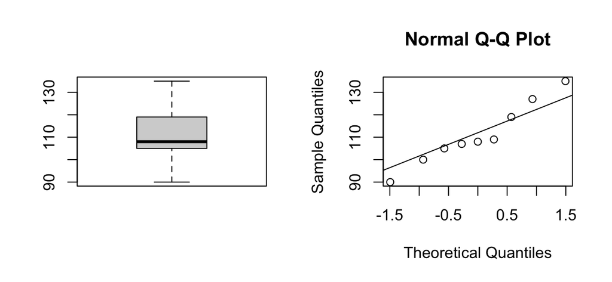

```r
par(mfrow = c(1, 2))
boxplot(iq)
qqnorm(iq)
qqline(iq)
```

It’s hard to be sure with only 9 observations. In the QQ plot, the points are reasonably close to the line, so the normality assumption probably isn’t wildly inappropriate, but let’s err on the side of caution and go with a non-parametric test anyway.

The table of differences $d_i=x_i-107$ is

| Subject | 1 | 2 | 3 | 4 | 5 | 6 | 7 | 8 | 9 |
| --- | --- | --- | --- | --- | --- | --- | --- | --- | --- |
| $x_i$ | 100 | 90 | 135 | 108 | 107 | 119 | 127 | 109 | 105 |
| $d_i = x_i - 107$ | -7 | -17 | 28 | 1 | 0 | 12 | 20 | 2 | -2 |
| $\vert d_i \vert$ | 7 | 17 | 28 | 1 | 0 | 12 | 20 | 2 | 2 |
| Rank of $\vert d_i \vert$, $r_i$ | 4 | 6 | 8 | 1 |  | 5 | 7 | 2.5 | 2.5 |
| Signed rank | -4 | -6 | 8 | 1 |  | 5 | 7 | 2.5 | -2.5 |

The effective sample size is $n=8$ as one of the differences is 0 (neither positive or negative).

The Wilcoxon signed-rank test for the IQ of the arrested abusers who are 16 or older from the population of interest is

**Hypotheses:** $H_0\colon\ \mu=107$ against $H_1\colon\ \mu > 107$.

**Assumption:** $X_i$ are independently sampled from a symmetric distribution.

**Test statistic:** $W^+ = \sum_{i:D_i>0}R_i$ where $D_i = X_i - 107$ and $R_i$ are the ranks of $|D_1|,|D_2|,\ldots,|D_n|$.

**Observed test statistic:** $w^+ = 8+1+5+7+2.5 = 23.5$ and $w^- = 4+6+2.5 = 12.5$

**p-value:** Since there are ties, normal approximation is used.

$\operatorname{E}(W^+) = \frac{n(n+1)}{4}=\frac{8(8+1)}{4}=18$

$\operatorname{Var}(W^+) = \frac{1}{4} \sum\limits_{i=1}^{8} r_i^{'2} = \frac{1}{4}[4^2+6^2+8^2 + \dots + 2.5^2]=\frac{203.5}{4}=50.875$

$P(W^+ \geq 23.5) = P\left(Z \geq \frac{23.5-18}{\sqrt{50.875}} \right) = P(Z \geq 0.77) = 0.220$

```r
library(tidyverse)
dat = tibble(iq)
dat = dat %>% mutate(
  d = iq - 107,
  abs_d = abs(d)
)
effective_dat = dat %>% filter(d !=0 )
effective_dat$r = rank(effective_dat$abs_d)
w_plus = sum(effective_dat$r[effective_dat$d > 0])
w_minus = sum(effective_dat$r[effective_dat$d < 0])
n = nrow(effective_dat)
ew = n*(n+1)/4
varw = sum(effective_dat$r^2)/4
c(ew, varw)
```

```
[1] 18.000 50.875
```

```r
t0 = (w_plus - ew)/(sqrt(varw))
p_val = 1 - pnorm(t0)
c(t0, p_val)
```

```
[1] 0.7710996 0.2203239
```

**Decision:** Since p-value is greater than 0.05, we do not reject $H_0$. The data is consistent with $H_0$ that the IQ of the arrested abusers who are 16 or older from the population of interest is 107.

```r
wilcox.test(iq, mu = 107, alternative = "greater", correct = FALSE)
```

```
    Wilcoxon signed rank test

data:  iq
V = 23.5, p-value = 0.2203
alternative hypothesis: true location is greater than 107
```

```r
# alternatively wilcox.test(iq - 107, alternative = 'greater',
# correct = FALSE)
```

There is a parameter for the `wilcox.test()` function that indicates if a continuity correction should be used when calculating the p-value using a normal approximation (i.e. when there are ties or when the sample size is large). The default is `correct = TRUE`. In examples when we’re comparing R output to our “manual” calculation I specify `correct = FALSE` to ensure the results match. In general though it’s fine (and probably better) to leave it as the default setting `correct = TRUE`. In large sample sizes the difference will be negligible.

## 2.2 Weight gain

The weight of 5 pigs on diet X and 5 pigs on diet Y are

Diet $X$: {12, 16, 16, 12, 10} and diet $Y$: {30, 12, 24, 32, 24}.

Test if there is a difference in weight using the Wilcoxon rank-sum test. What is the corresponding p-value?

1. $P(Z<-2.02) = 0.02$
2. $2P(Z<-2.02) = 0.04$
3. $P(Z<-0.43) = 0.33$
4. $2P(Z>-0.43) = 0.66$

```r
wdat = data.frame(
  weight = c(12, 16, 16, 12, 10, 30, 12, 24, 32, 24),
  diet = rep(c("X","Y"), each = 5)
)
```

We have $n_x = n_y=5$ and $N = 10$. The ranks for the combined sample are

```r
library(dplyr)
wdat = wdat %>%
    mutate(ranks = rank(weight))
wdat
```

```
   weight diet ranks
1      12    X   3.0
2      16    X   5.5
3      16    X   5.5
4      12    X   3.0
5      10    X   1.0
6      30    Y   9.0
7      12    Y   3.0
8      24    Y   7.5
9      32    Y  10.0
10     24    Y   7.5
```

```r
wdat %>%
    group_by(diet) %>%
    summarise(sum(ranks))
```

```
# A tibble: 2 × 2
  diet  `sum(ranks)`
  <chr>        <dbl>
1 X               18
2 Y               37
```

Or a manual method of finding ranks:

| Group | X | X | X | X | X | Y | Y | Y | Y | Y |  |
| --- | --- | --- | --- | --- | --- | --- | --- | --- | --- | --- | --- |
| Weight | 12 | 16 | 16 | 12 | 10 | 30 | 12 | 24 | 32 | 24 |  |
| — | — | — | — | — | — | — | — | — | — | — |  |
| Ordered weight | 10 | 12 | 12 | 12 | 16 | 16 | 24 | 24 | 30 | 32 |  |
| Ordered group | X | X | X | Y | X | X | Y | Y | Y | Y |  |
| Successive rank | 1 | 2 | 3 | 4 | 5 | 6 | 7 | 8 | 9 | 10 |  |
| Ranks | 1 | 3 | 3 | 3 | 5.5 | 5.5 | 7.5 | 7.5 | 9 | 10 |  |

Let $\mu_x$ and $\mu_y$ be the population mean weight for pigs on diets X and Y, respectively. The Wilcoxon rank-sum test for the difference between diet X and Y is

**Hypotheses:** $H_0\colon\ \mu_x=\mu_y$ vs $H_1\colon\ \mu_x \ne \mu_y.$

**Assumptions:** $X_i$ and $Y_i$ are independent and follow the same type of distribution, differing only by a shift.

**Test statistic:** $W = R_1 + R_2 + \ldots + R_{n_x}$ (the sum of the ranks of observations in diet X). Under $H_0$, $W \sim \operatorname{WRS}'(5,5)$, the Wilcoxon rank sum distribution with sizes 5, 5 and with ties as shown.

**Observed test statistic:** $W = 3+5.5+5.5+3+1 = 18$

**p-value:** $2 P(W \le 18)$. Since there are ties, we should use normal approximation to the distribution of $W$ or derive the exact distribution of $W$. In this case, it doesn’t matter whether one sums the ranks from the smaller or larger sample or whether the sum is in the lower or upper range.

$\operatorname{E}(W) = \frac{n_x(N + 1)}{2} = \frac{5\times (10 + 1)}{2}=27.5$

$\frac{N(N + 1)^2}{4} = \frac{10(10 + 1)^2}{4} = 302.5$

$\operatorname{Var}(W) = \frac{n_x n_y}{N(N-1)} \left( \sum_{i=1}^N r_i^2-\frac{N(N+1)^2}{4} \right) = \frac{5(5)(382-302.5)}{10(9)} = 22.083$

$2 P(W \leq 18) \approx 2 P\left(Z \leq \frac{w-\operatorname{E}(W)}{\sqrt{\operatorname{Var}(W)}} \right) = 2P\left(Z \leq \frac{18-27.5}{\sqrt{22.083}} \right) = 2P(Z \leq -2.02) = 0.04$

```r
nx = 5
ny = 5
N = nx + ny
ew = nx * (N + 1)/2
varw = (sum(wdat$ranks^2) - N * (N + 1)^2/4) * nx * ny/(N * (N - 1))
c(ew, varw)
```

```
[1] 27.50000 22.08333
```

```r
w = sum(wdat$ranks[wdat$diet == "X"])
t0 = (w - ew)/sqrt(varw)
p_value = 2 * pnorm(t0)
c(w, t0, p_value)
```

```
[1] 18.00000000 -2.02158167  0.04321959
```

**Decision:** Since the p-value is less than 0.05 there is evidence against $H_0$. There is evidence of a significant difference in the population mean weights of pigs using diets X and Y.

```r
wilcox.test(weight ~ diet, data = wdat, correct = FALSE)
```

```
    Wilcoxon rank sum test

data:  weight by diet
W = 3, p-value = 0.04322
alternative hypothesis: true location shift is not equal to 0
```

## 2.3 How fast can you type?

Ten executive assistants were selected at random from among the executive assistants at a large university. The typing speed (number of words per minute) was recorded for each executive assistant on two different brands of computer keyboards. The following results were obtained.

| Executive Assistant | Brand A | Brand B |
| --- | --- | --- |
| Amy | 74 | 72 |
| Bruce | 80 | 86 |
| Carol | 68 | 72 |
| Dion | 74 | 70 |
| Ellen | 86 | 85 |
| Fred | 75 | 73 |
| Gwen | 78 | 72 |
| Hugh | 69 | 65 |
| Ingrid | 76 | 79 |
| Kenneth | 77 | 75 |

```r
x = data.frame(
  ea = c("Amy", "Bruce", "Carol", "Dion",
                "Ellen", "Fred", "Gwen", "Hugh",
                "Ingrid", "Kenneth"),
  brand_a = c(74, 80, 68, 74, 86, 75, 78, 69, 76, 77),
  brand_b = c(72, 86, 72, 70, 85, 73, 72, 65, 79, 75)
)
```

1. Add a column called `diff` to the data frame `x` that equals the difference between the Brand A speeds and the Brand B speeds. Also add a column `ranks` that has the ranks of the absolute values of the differences.
2. Generate diagnostic plots to ascertain whether or not the differences are normally distributed. Discuss, with reference to the diagnostic plots, why you think the differences can or cannot be reasonably assumed to follow a normal distribution.
3. Perform the **sign test** to determine if these data provide enough evidence at the 5% significance level to infer that the brands differ with respect to typing speed.
4. Perform the **Wilcoxon signed-rank test** at the 5% level of significance.
5. Use R to calculate the p-value for the paired $t$-test. Does the paired $t$-test come to the same decision as the sign test and Wilcoxon signed-rank test?
6. Which test is better, the **sign test**, **Wilcoxon signed-rank test** or **paired $t$-test**? Why?
1. By hand, the table of differences is

| $d_i = a_i - b_i$ | 2 | -6 | -4 | 4 | 1 | 2 | 6 | 4 | -3 | 2 |
| --- | --- | --- | --- | --- | --- | --- | --- | --- | --- | --- |
| $\vert d_i \vert$ | 2 | 6 | 4 | 4 | 1 | 2 | 6 | 4 | 3 | 2 |
| Rank of $\vert d_i \vert$, $r_i$ | 3 | 9.5 | 7 | 7 | 1 | 3 | 9.5 | 7 | 5 | 3 |
| Signed rank | 3 | -9.5 | -7 | 7 | 1 | 3 | 9.5 | 7 | -5 | 3 |

In R:

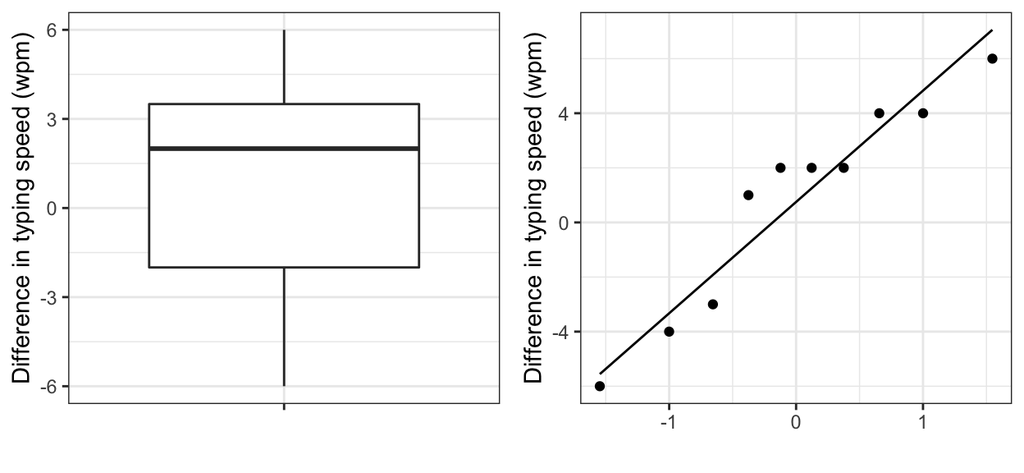

```r
x = x %>%
  mutate(
    diff = brand_a - brand_b,
    ranks = rank(abs(diff))
  )
library(ggplot2)
p1 = ggplot(x, aes(x = "", y = diff)) +
  geom_boxplot() + theme_bw() +
  labs(y = "Difference in typing speed (wpm)", x="")
p2 = ggplot(x, aes(sample = diff)) +
  geom_qq() +
  geom_qq_line() +
  theme_bw() +
  labs(y = "Difference in typing speed (wpm)", x="")
gridExtra::grid.arrange(p1, p2, ncol=2)
```

2. In the boxplot, the median isn’t quite in the centre of the box and the top whisker is slightly shorter than the bottom whisker which indicates a left skew distribution. However, in the QQ plot the points all lie reasonably close to the diagonal line which suggests that the differences are approximately normally distributed.
3. The **sign test** for the difference in typing speeds for executive assistants on two different brands of computer keyboards is

   **Hypotheses:** $H_0\colon\ p_+=\frac{1}{2}$ against $H_1\colon\ p_+ \ne \frac{1}{2}$.

   **Assumptions:** Differences, $D_i = A_i - B_i$, are independent.

   **Test statistic:** $T = \#(D_i>0)$. Under $H_0$, $T \sim {\mathcal{B}}(10, 0.5)$.

   **Observed test statistic:** $t_0 = \#(d_i>0) = 7$.

   **p-value:**
   $$\begin{align*}
   2P(X\geq 7) & = 2\sum_{i=7}^{10} \left( \begin{array}{c} 10 \\ i \end{array} \right) 0.5^i 0.5^{10-i} \\
   & = 2 \times 0.5^{10} \left[ \binom{10}{7} + \binom{10}{8} + \binom{10}{9} + \binom{10}{10} \right] \\
   & = 2 \times 0.000977[10\times 9 \times 8/(3\times 2) + 10(9)/2 + 10+1] \\
   & = 2 \times 0.1719 = 0.3438
   \end{align*}$$

   **Decision:** Since the p-value is greater than 0.05, we do not reject $H_0$ and conclude that there is no difference in the typing speeds for executive assistants on two different brands of computer keyboards.

   ```r
   t0 = sum(x$diff > 0)
    n = sum(x$diff != 0)
    c(t0, n)
   ```

   ```
   [1]  7 10
   ```

   ```r
   2 * sum(dbinom(t0:n, n, 1/2))
   ```

   ```
   [1] 0.34375
   ```

   ```r
   binom.test(t0, n)
   ```

   ```
       Exact binomial test

   data:  t0 and n
   number of successes = 7, number of trials = 10, p-value =
   0.3438
   alternative hypothesis: true probability of success is not equal to 0.5
   95 percent confidence interval:
    0.3475471 0.9332605
   sample estimates:
   probability of success
                      0.7
   ```

4. The Wilcoxon signed-rank test:

   **Hypotheses:** $H_0\colon\ \mu_d=0$ against $H_1\colon\ \mu_d \ne 0$.

   **Assumptions:** $D_i = A_i - B_i$ are independently sampled from a symmetric distribution.

   **Test statistic:** $W^+ = \sum_{i:D_i>0}R_i$ where $R_i$ are the ranks of $|D_1|,|D_2|,\ldots,|D_n|$.

   **Observed test statistic:** $w^+ = 33.5$, $w^- = 21.5$, $w = \min(w^+, w^-) = 21.5$.

   **p-value:** $2P(W \leq 21.5)$. We can use the normal approximation, noting that $\operatorname{E}(W^+) = \frac{n(n+1)}{4}=\frac{10(10+1)}{4}=27.5$ and $\operatorname{Var}(W^+) = \frac{1}{4} \sum\limits_{i=1}^{10} r_i^2 = \frac{380.5}{4}=95.125$,
   $$\begin{align*}
   2P(W \le 21.5) & \approx 2P\left(Z \leq \frac{w - \operatorname{E}(W^+)}{\sqrt{\operatorname{Var}(W^+)}} \right) \\
   & = 2P\left(Z \leq \frac{21.5-27.5}{\sqrt{95.125}} \right) \\
   & = 2P(Z \leq -0.6152) \\
   & = 2 \times 0.2692 \\
   & = 0.5384
   \end{align*}$$

   **Decision:** As the p-value is greater than 0.05, we do not reject $H_0$. The data is consistent with $H_0$ that there is no difference in the typing speeds for executative assistants on two different brands of computer keyboards.

   ```r
   w_plus = sum(x$ranks[x$diff > 0])
    w_minus = sum(x$ranks[x$diff < 0])
    w = min(w_plus, w_minus)
    n = length(x$ranks)
    c(w_plus, w_minus, w, n)
   ```

   ```
   [1] 33.5 21.5 21.5 10.0
   ```

   ```r
   ew = n * (n + 1)/4
    varw = sum(x$ranks^2)/4
    t0 = (w - ew)/sqrt(varw)
    p_value = 2 * pnorm(t0)
    c(t0, p_value)
   ```

   ```
   [1] -0.6151824  0.5384343
   ```

   ```r
   wilcox.test(x$diff, correct = FALSE)
   ```

   ```
       Wilcoxon signed rank test

   data:  x$diff
   V = 33.5, p-value = 0.5384
   alternative hypothesis: true location is not equal to 0
   ```

5. The paired $t$-test can be calculated in R as follows:

   ```r
   t.test(x$diff)
   ```

   ```
       One Sample t-test

   data:  x$diff
   t = 0.65175, df = 9, p-value = 0.5309
   alternative hypothesis: true mean is not equal to 0
   95 percent confidence interval:
    -1.976715  3.576715
   sample estimates:
   mean of x
         0.8
   ```

## 2.4 Rats teaching rats

From a group of nine rats available for a study of transfer of learning, five were selected at random and were trained to imitate leader rats in a maze. They were then placed together with four untrained control rats in a situation where imitation of the leaders enable them to avoid receiving an electric shock. The results (the number of trials required to obtain ten correct responses in ten consecutive trials) were as follows:

Trained rats: {78, 64, 75, 45, 82} and Controls: {110, 70, 53, 51}.

Test if there is a difference in the number of trials required between the trained rats and the controls using the Wilcoxon rank-sum test given the following probabilities:

```r
data.frame(x = 0:10, p = round(pwilcox(0:10, m = 4, n = 5), 4))
```

```
    x      p
1   0 0.0079
2   1 0.0159
3   2 0.0317
4   3 0.0556
5   4 0.0952
6   5 0.1429
7   6 0.2063
8   7 0.2778
9   8 0.3651
10  9 0.4524
11 10 0.5476
```

The ranks for the combined sample are

| Trained | 78 | 64 | 75 | 45 | 82 | Control | 110 | 70 | 53 | 51 |
| --- | --- | --- | --- | --- | --- | --- | --- | --- | --- | --- |
| Ranks | 7 | 4 | 6 | 1 | 8 |  | 9 | 5 | 3 | 2 |

Let $\mu_x$ and $\mu_y$ be the population means for the trained and control groups, respectively. The Wilcoxon rank-sum test is

**Hypotheses:** $H_0\colon\ \mu_x = \mu_y$ vs $H_1\colon\ \mu_x \neq \mu_y$

**Assumptions:** $X_i$ and $Y_i$ are independent and follow the same distribution but differ by a shift.

**Test statistic:** $W = R_1 + R_2 + \ldots + R_{n_y}$. Under $H_0$, $W$ follows the $WRS(4, 5)$ distribution.

**Observed test statistic:** $w = 9+5+3+2 = 19$

**p-value:** $2 P(W \leq 19) = 2 \times 0.4524 = 0.9048$

$\min(W) = \frac{n_y(n_y + 1)}{2} = 10$, so

```r
pwilcox(19 - 10, m = 4, n = 5)
```

```
[1] 0.452381
```

**Decision:** Since the p-value is greater than 0.05, we conclude that the data is consistent with $H_0$. There are no differences in the number of trials required between the trained rats and the controls.

In R:

```r
rats = data.frame(
  trials = c(78, 64, 75, 45, 82, 110, 70, 53, 51),
  treatment = rep(c("Trained", "Control"), times = c(5, 4))
)
wilcox.test(trials ~ treatment, data = rats)
```

```
    Wilcoxon rank sum exact test

data:  trials by treatment
W = 9, p-value = 0.9048
alternative hypothesis: true location shift is not equal to 0
```

# 3 For practice after the computer lab

Read sections 14.1, 14.2 and 14.3 from Larsen and Marx (2012). You can look at questions 14.2.1, 14.2.2, 14.2.6, 14.2.7, 14.2.8, 14.2.9, 14.2.11, 14.3.1, 14.3.3, 14.3.4, 14.3.5, 14.3.6, 14.3.7, 14.3.8, 14.3.9 and 14.3.10.

## 3.1 Thinking about the WSR test statistic

When performing a Wilcoxon signed-rank test, in the event that there are no ties, you can calculate the exact p-value by deriving the exact distribution. Let $W^+$ be the Wilcoxon signed-rank distribution. When $n=3$, find all the probabilities $P(W^+ \le w^+)$ for $w^+ = 0,1,2, ...$ [Hint: How many ways can you get each possible $w^+$ outcome?] Check your answers with the `psignrank()` function.

There are $2^3=8$ possible signed ranks

$$\begin{array}{rlrl}
1, 2, 3 \ & w^+=6; & -1, -2, -3 & w^+=0 \\
-1, 2, 3 \ & w^+=5; & 1, -2, -3 & w^+=1 \\
1, -2, 3 \ & w^+=4; & -1, 2, -3 & w^+=2 \\
1, 2, -3 \ & w^+=3; & -1, -2, 3 & w^+=3 \\
\end{array}$$

Each with probability $\frac{1}{8}$ under $H_0$. Thus

$$\begin{align*}
P(w^+ \le 0) & = \frac{1}{8} = 0.125 \\
P(w^+ \le 1) & = \frac{2}{8} = 0.250 \\
P(w^+ \le 2) & = \frac{3}{8} = 0.375 \\
P(w^+ \le 3) & = \frac{5}{8} = 0.625 \\
P(w^+ \le 4) & = \frac{6}{8} = 0.750 \\
P(w^+ \le 5) & = \frac{7}{8} = 0.875 \\
P(w^+ \le 6) & = \frac{8}{8} = 1 \\
\end{align*}$$

```r
dsignrank(0:6, n = 3)
```

```
[1] 0.125 0.125 0.125 0.250 0.125 0.125 0.125
```

```r
psignrank(0:6, n = 3)
```

```
[1] 0.125 0.250 0.375 0.625 0.750 0.875 1.000
```

Champely, Stephane. 2020. *Pwr: Basic Functions for Power Analysis*. https://CRAN.R-project.org/package=pwr.

Larsen, Richard J., and Morris L. Marx. 2012. *An Introduction to Mathematical Statistics and Its Applications*. 5th ed. Boston, MA: Prentice Hall.

Wickham, Hadley, Mara Averick, Jennifer Bryan, Winston Chang, Lucy D’Agostino McGowan, Romain François, Garrett Grolemund, et al. 2019. “Welcome to the tidyverse.” *Journal of Open Source Software* 4 (43): 1686. https://doi.org/10.21105/joss.01686.